# residential_displacement

suzanne

3/31/2022

## Residential Displacement Analysis

This document looks at residential displacement data from the 2019 and 2021 travel surveys.

What share of households experienced residential displacement in 2019 and 2021?

To lookup variable names the codebook is here: J:\Data\Combined_Codebook_2021_With_Weights.xlsx

We will use the psrc.travesurvey package, documentation is here: https://psrc.github.io/psrc.travelsurvey/articles/calculate_hhts_summaries.html

Code is here: https://github.com/psrc/psrc.travelsurvey

3,044 households answered res_dur in 2019 2, 793 household answered res_dur in 2021

```r
library(psrc.travelsurvey)
library(dplyr)
library(stringr)
library(tidyr)
```

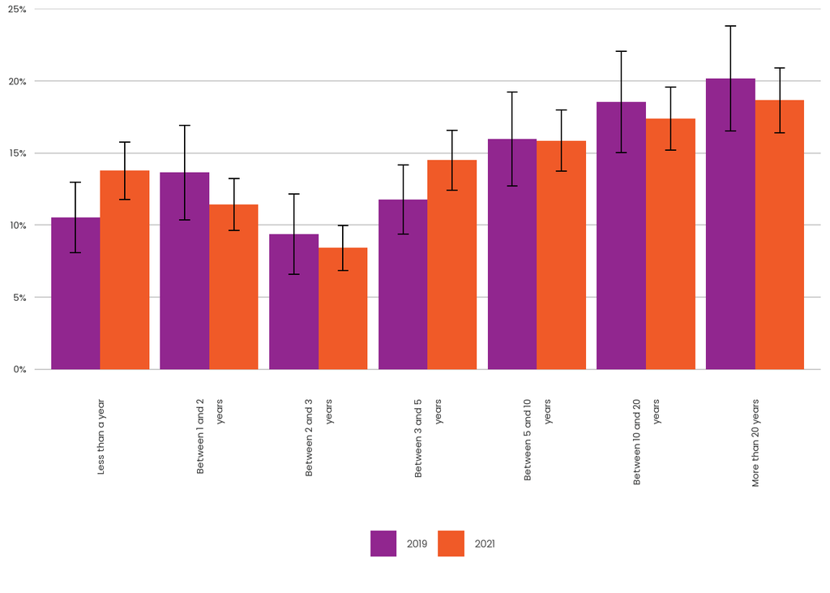

```r
library(psrcplot)
library(ggplot2)
library(forcats)
library(data.table)
psrcplot::install_psrc_fonts()

res_dur_2019<-get_hhts(survey='2019', level="h", vars="res_dur")
res_dur_2019_counts<- hhts_count(df=res_dur_2019, group_vars='res_dur')


res_dur_2021<-get_hhts(survey='2021', level="h", vars="res_dur")
res_dur_2021_counts<- hhts_count(df=res_dur_2021, group_vars='res_dur')

res_dur_2019_2021_counts<-rbind(res_dur_2019_counts, res_dur_2021_counts)%>%
filter(res_dur!='Total')%>%mutate(res_dur_ordered=factor(res_dur, levels= c('Less than a year', 'Between 1 and 2 years',
                                                                    'Between 2 and 3 years', 'Between 3 and 5 years',
                                                                    'Between 5 and 10 years', 'Between 10 and 20 years', 'More than 20 years', ordered=TRUE)))


static_column_chart(t=res_dur_2019_2021_counts, x='res_dur_ordered', y='share', fill='survey', moe='share_moe',color=  "pognbgy_5")+ theme(axis.text.x = element_text(angle = 90, vjust = 0.5, hjust=1))
```

There may have been more movers in 2021 in the past year as compared to 2019.

Let’s analyze 2019 movers in the past 5 years for residential displacement (by itself first). Look at 1. prev_res_factors, 2. res_factors 3. by income, 4. by race and ethnicity;

this is 987 households. In the past five years for movers in WA, 29% of households had experienced displacement related reasons for moving.

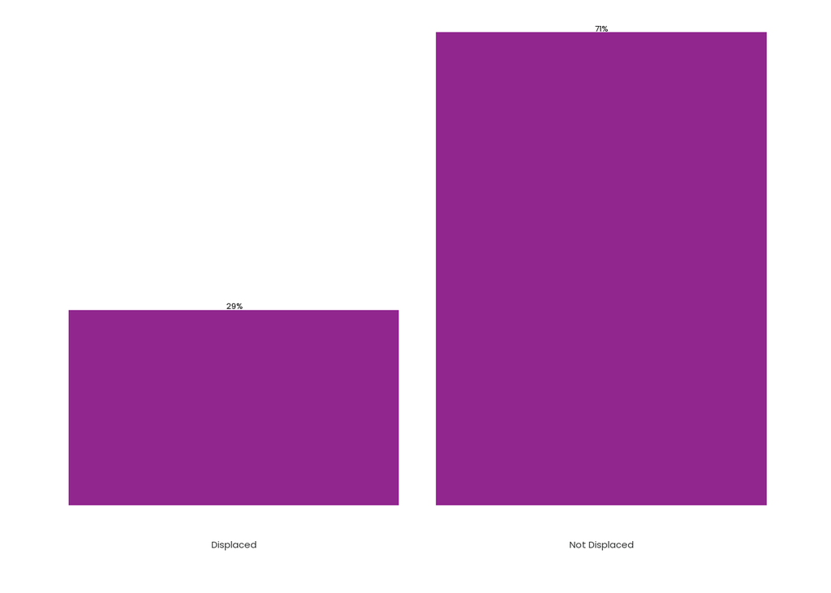

```r
displaced_hh_2019<-get_hhts(survey='2019', level="h", vars=c("prev_res_factors_displaced", 'res_dur', 'prev_home_wa'))%>%filter(res_dur %in% c('Less than a year', '    Between 1 and 2 years', 'Between 2 and 3 years',    'Between 3 and 5 years') & prev_home_wa =='Yes, previous home was in Washington')%>% mutate(prev_res_factors_displaced = replace_na(prev_res_factors_displaced,'No response'))
displaced_hh_2019_counts<- hhts_count(df=displaced_hh_2019, group_vars='prev_res_factors_displaced')%>%
filter(prev_res_factors_displaced!='Total')

static_column_chart(t=displaced_hh_2019_counts, x='prev_res_factors_displaced', y='share', fill='survey',color=  "pognbgy_5")
```

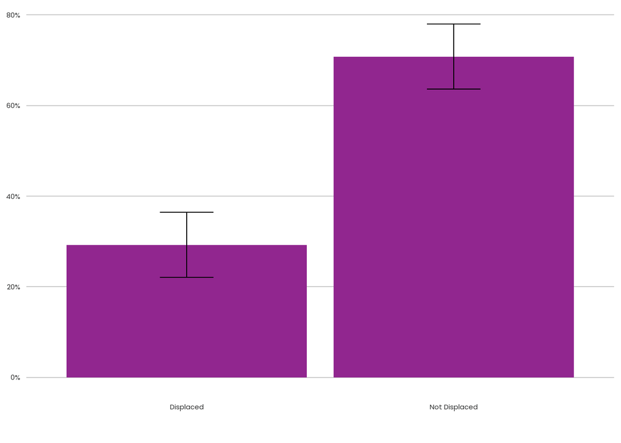

```r
displaced_hh_2019<-get_hhts(survey='2019', level="h", vars=c("prev_res_factors_displaced", 'res_dur', 'prev_home_wa', 'hh_race_category', 'hhincome_broad' ))%>%filter(res_dur %in% c('Less than a year', ' Between 1 and 2 years', 'Between 2 and 3 years',    'Between 3 and 5 years') & prev_home_wa =='Yes, previous home was in Washington')%>% mutate(prev_res_factors_displaced = replace_na(prev_res_factors_displaced,'No response'))%>%mutate(hhincome_100_f=factor(hhincome_broad, levels=c("Under $25,000" , "$25,000-$49,999" ,  "$50,000-$74,999" , "$75,000-$99,999", "$100,000 or more",'$200,000 or more', "Prefer not to answer")))



displaced_hh_2019_counts<- hhts_count(df=displaced_hh_2019, group_vars='prev_res_factors_displaced')%>%
filter(prev_res_factors_displaced!='Total')

static_column_chart(t=displaced_hh_2019_counts, x='prev_res_factors_displaced', y='share', fill='survey', moe='share_moe',color=  "pognbgy_5")
```

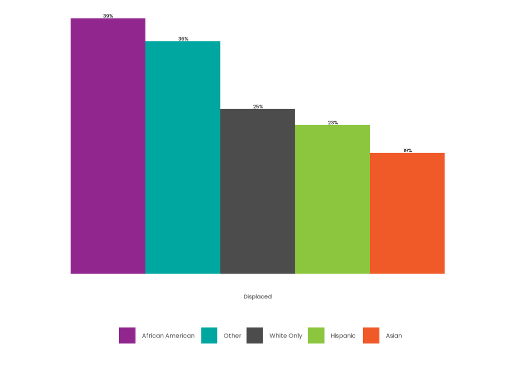

```r
displaced_hh_2019_counts<- hhts_count(df=displaced_hh_2019, group_vars=c('hh_race_category','prev_res_factors_displaced'))%>%
filter(prev_res_factors_displaced!='Total')%>%
  filter(hh_race_category!='Total')%>%filter(prev_res_factors_displaced=='Displaced')%>%
  filter(hh_race_category != 'Missing') %>%
  mutate(hh_race_high_low= fct_reorder(hh_race_category, -share))

static_column_chart(t=displaced_hh_2019_counts, x='prev_res_factors_displaced', y='share', fill='hh_race_high_low',color=  "pognbgy_10")
```

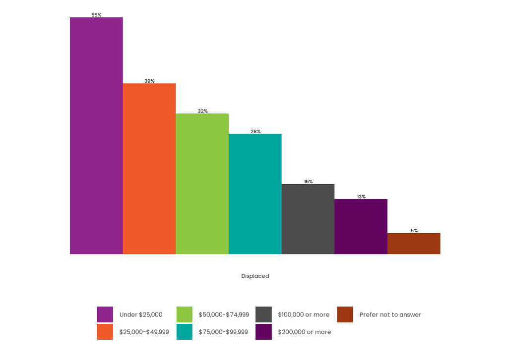

```r
displaced_hh_2019_counts<- hhts_count(df=displaced_hh_2019, group_vars=c('hhincome_100_f','prev_res_factors_displaced'))%>%
filter(prev_res_factors_displaced!='Total')%>%filter(hhincome_100_f !='Total')%>%filter(prev_res_factors_displaced=='Displaced')

static_column_chart(t=displaced_hh_2019_counts, x='prev_res_factors_displaced', y='share', fill='hhincome_100_f',color=  "pognbgy_10")
```

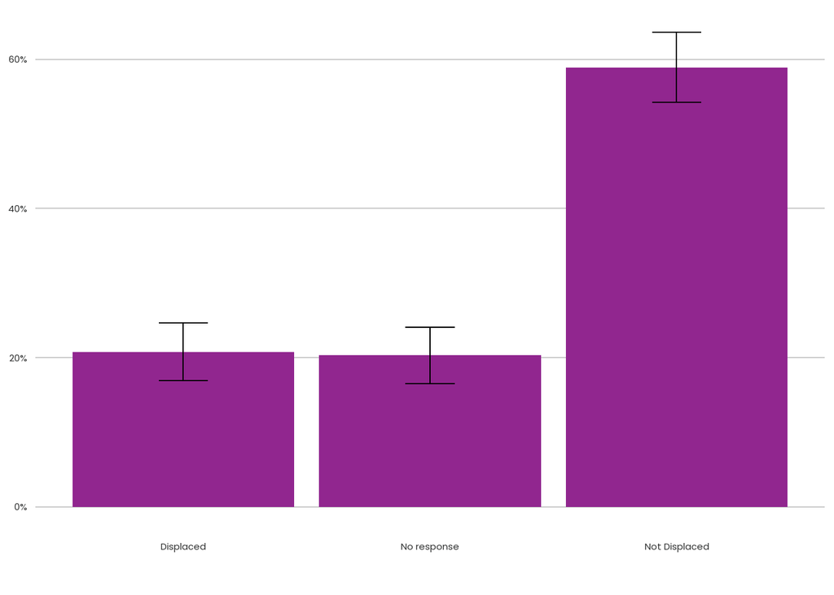

```r
displaced_hh_2021<-get_hhts(survey='2021', level="h", vars=c("prev_res_factors_displaced", 'res_dur', 'prev_home_wa', 'hh_race_category', 'hhincome_broad' ))%>%filter(res_dur %in% c('Less than a year', ' Between 1 and 2 years', 'Between 2 and 3 years',    'Between 3 and 5 years'))%>% mutate(prev_res_factors_displaced = replace_na(prev_res_factors_displaced,'No response'))%>%mutate(hhincome_100_f=factor(hhincome_broad, levels=c("Under $25,000" , "$25,000-$49,999" ,  "$50,000-$74,999" , "$75,000-$99,999", "$100,000-$199,000",'$200,000 or more', "Prefer not to answer")))



displaced_hh_2021_counts<- hhts_count(df=displaced_hh_2021, group_vars='prev_res_factors_displaced')%>%
filter(prev_res_factors_displaced!='Total')

static_column_chart(t=displaced_hh_2021_counts, x='prev_res_factors_displaced', y='share', fill='survey', moe='share_moe',color=  "pognbgy_5")
```

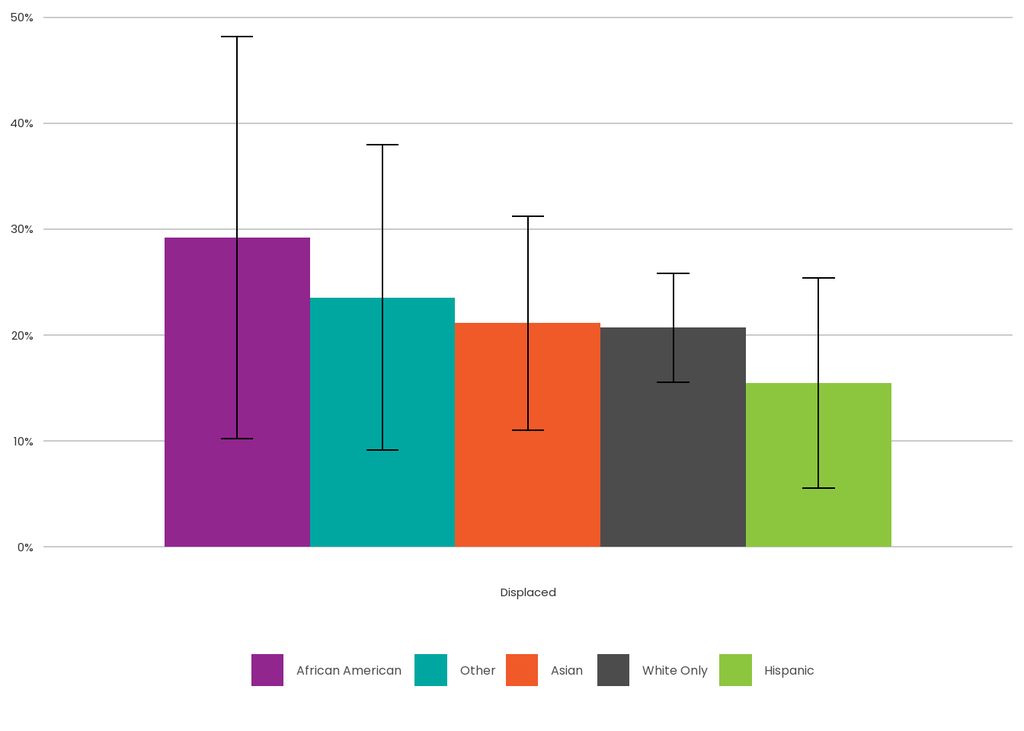

```r
displaced_hh_2021_counts<- hhts_count(df=displaced_hh_2021, group_vars=c('hh_race_category','prev_res_factors_displaced'))%>%
filter(prev_res_factors_displaced!='Total')%>%
  filter(hh_race_category!='Total')%>%filter(prev_res_factors_displaced=='Displaced')%>%
  filter(hh_race_category != 'Missing') %>%
  mutate(hh_race_high_low= fct_reorder(hh_race_category, -share))

static_column_chart(t=displaced_hh_2021_counts, x='prev_res_factors_displaced', y='share', fill='hh_race_high_low',color=  "pognbgy_10", moe='share_moe')
```

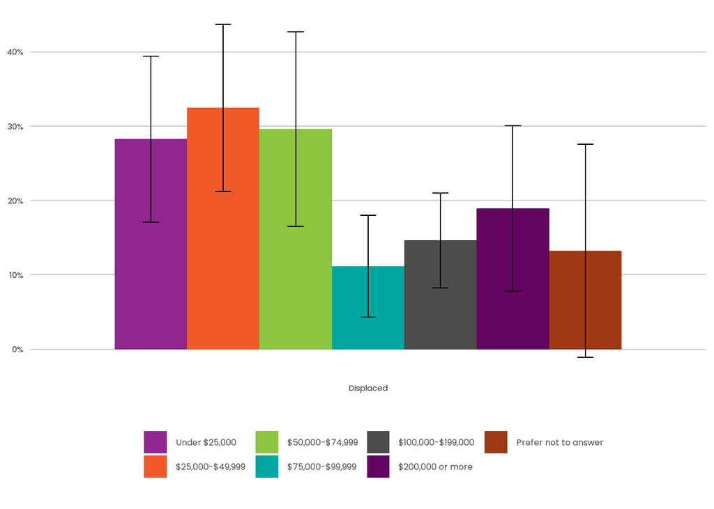

```r
displaced_hh_2021_counts<- hhts_count(df=displaced_hh_2021, group_vars=c('hhincome_100_f','prev_res_factors_displaced'))%>%
filter(prev_res_factors_displaced!='Total')%>%filter(hhincome_100_f !='Total')%>%filter(prev_res_factors_displaced=='Displaced')

static_column_chart(t=displaced_hh_2021_counts, x='prev_res_factors_displaced', y='share', fill='hhincome_100_f',color=  "pognbgy_10", moe='share_moe')
```

In 2019, there was a strong correlation between income and experiencing displacement. 55% of hhs with incomes of less than $25K experienced displacement. 13% of households with incomes over 200K

39% of African American hhs, 36% of other hhs experienced displacement, at higher rates than White Only, Hispanic, and Asian HHs

Both datasets in the past 5 years (there is overlap in the time frame); no statistically significant difference (987 hhs in 2019, 860 in 2021)

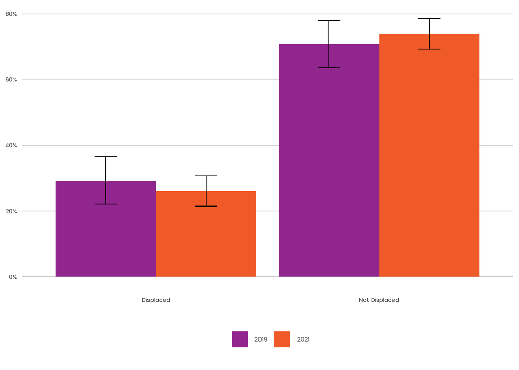

```r
displaced_hh_2019<-get_hhts(survey='2019', level="h", vars=c("prev_res_factors_displaced", 'res_dur', 'prev_home_wa'))%>%filter(res_dur %in% c('Less than a year', '    Between 1 and 2 years', 'Between 2 and 3 years',    'Between 3 and 5 years') & prev_home_wa =='Yes, previous home was in Washington')%>% mutate(prev_res_factors_displaced = replace_na(prev_res_factors_displaced,'No response'))
displaced_hh_2019_counts<- hhts_count(df=displaced_hh_2019, group_vars='prev_res_factors_displaced')%>%
filter(prev_res_factors_displaced!='Total')

displaced_hh_2021<-get_hhts(survey='2021', level="h", vars=c("prev_res_factors_displaced", 'res_dur', 'prev_home_wa'))%>%filter(res_dur %in% c('Less than a year', '    Between 1 and 2 years', 'Between 2 and 3 years',    'Between 3 and 5 years') & prev_home_wa =='Yes, previous home was in Washington')%>% mutate(prev_res_factors_displaced = replace_na(prev_res_factors_displaced,'No response'))
displaced_hh_2021_counts<- hhts_count(df=displaced_hh_2021, group_vars='prev_res_factors_displaced')%>%
filter(prev_res_factors_displaced!='Total')

displaced_2019_2021_counts<-rbind(displaced_hh_2019_counts, displaced_hh_2021_counts)%>%
filter(prev_res_factors_displaced!='Total')

static_column_chart(t=displaced_2019_2021_counts, x='prev_res_factors_displaced', y='share', fill='survey', moe='share_moe',color=  "pognbgy_5")
```

` Both datasets in the past 2 years NO overlap; 361 hhs in 2019; 298 hhs in 2021; 42% of hhs to 28%

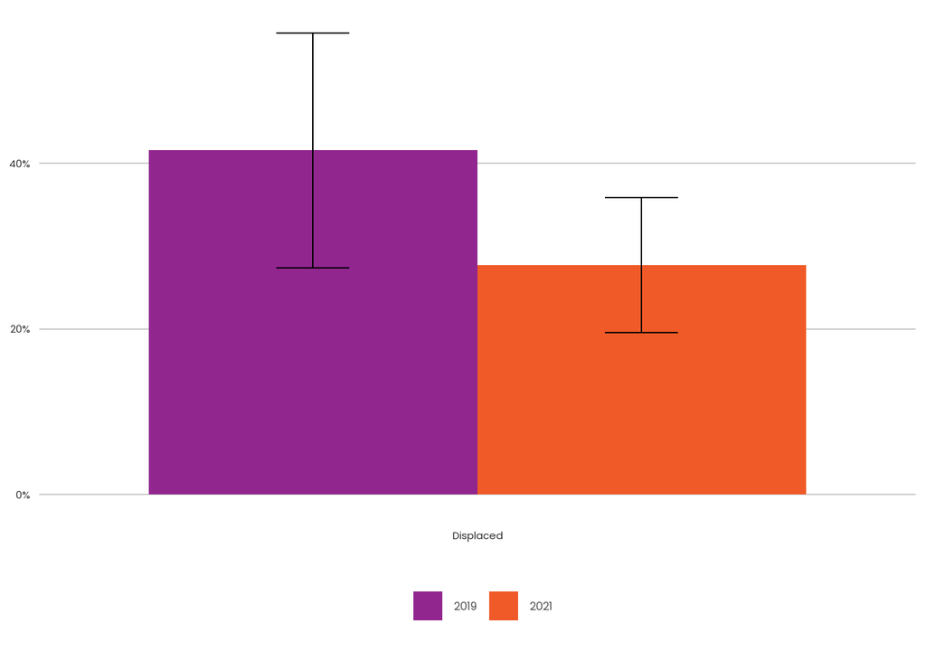

```r
displaced_hh_2019<-get_hhts(survey='2019', level="h", vars=c("prev_res_factors_displaced", 'res_dur', 'prev_home_wa'))%>%filter(res_dur %in% c('Less than a year', '    Between 1 and 2 years') & prev_home_wa =='Yes, previous home was in Washington')%>% mutate(prev_res_factors_displaced = replace_na(prev_res_factors_displaced,'No response'))
displaced_hh_2019_counts<- hhts_count(df=displaced_hh_2019, group_vars='prev_res_factors_displaced')%>%
filter(prev_res_factors_displaced!='Total')

displaced_hh_2021<-get_hhts(survey='2021', level="h", vars=c("prev_res_factors_displaced", 'res_dur', 'prev_home_wa'))%>%filter(res_dur %in% c('Less than a year', '    Between 1 and 2 years' ) & prev_home_wa =='Yes, previous home was in Washington')%>% mutate(prev_res_factors_displaced = replace_na(prev_res_factors_displaced,'No response'))
displaced_hh_2021_counts<- hhts_count(df=displaced_hh_2021, group_vars='prev_res_factors_displaced')%>%
filter(prev_res_factors_displaced!='Total')

displaced_2019_2021_counts<-rbind(displaced_hh_2019_counts, displaced_hh_2021_counts)%>%
filter(prev_res_factors_displaced!='Total')%>%filter(prev_res_factors_displaced=='Displaced')

static_column_chart(t=displaced_2019_2021_counts, x='prev_res_factors_displaced', y='share', fill='survey', moe='share_moe',color=  "pognbgy_5")
```

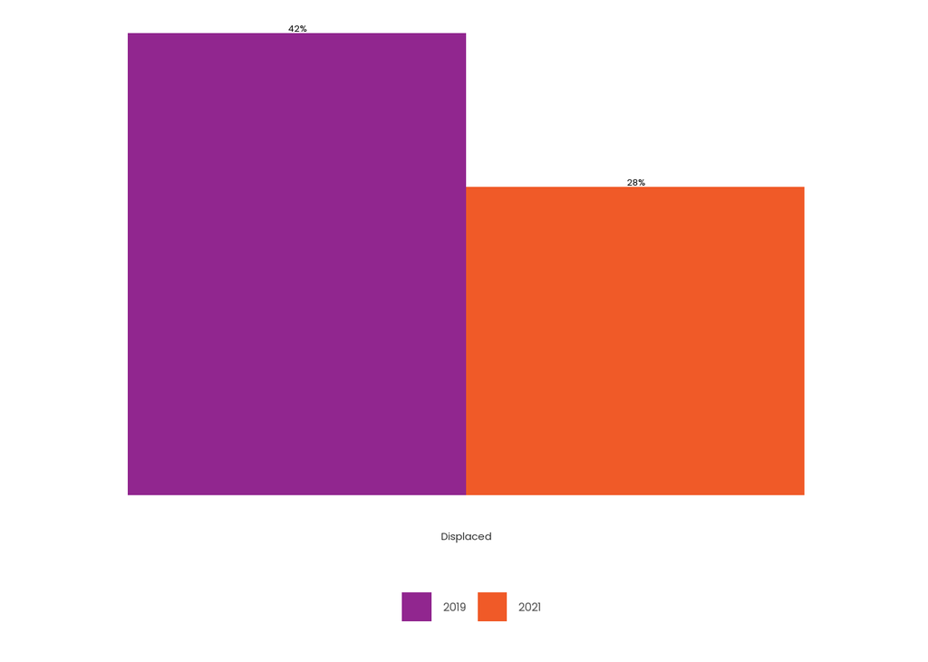

```r
static_column_chart(t=displaced_2019_2021_counts, x='prev_res_factors_displaced', y='share', fill='survey',color=  "pognbgy_5")
```

Showing displacement by time period. this part is a little tricky; i think I need someone to check me.

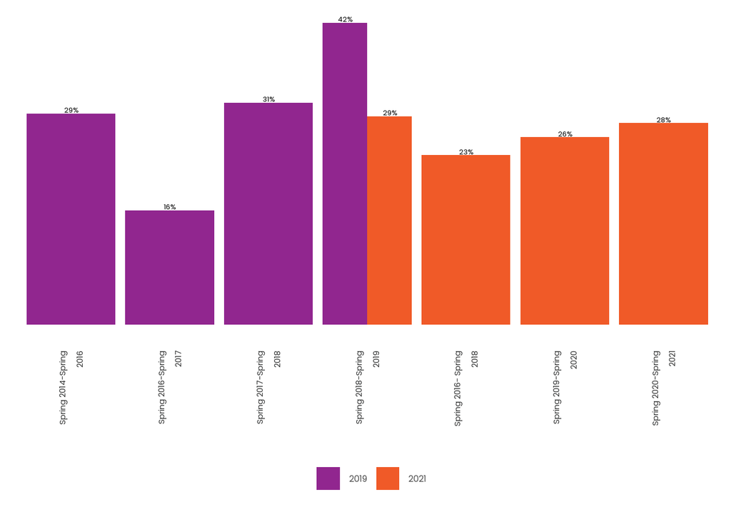

```r
displaced_hh_2019<-get_hhts(survey='2019', level="h", vars=c("prev_res_factors_displaced", 'res_dur', 'prev_home_wa'))%>%filter(res_dur %in% c('Less than a year', 'Between 1 and 2 years', 'Between 2 and 3 years',    'Between 3 and 5 years') & prev_home_wa =='Yes, previous home was in Washington')%>% mutate(prev_res_factors_displaced = replace_na(prev_res_factors_displaced,'No response'))%>%mutate(move_year= case_when(
  res_dur =='Less than a year' ~ 'Spring 2018-Spring 2019',
  res_dur == 'Between 1 and 2 years' ~ 'Spring 2017-Spring 2018',
  res_dur == 'Between 2 and 3 years' ~ 'Spring 2016-Spring 2017',
  res_dur == 'Between 3 and 5 years' ~ 'Spring 2014-Spring 2016'

))
displaced_hh_2019_counts<- hhts_count(df=displaced_hh_2019, group_vars= c( 'move_year','prev_res_factors_displaced'))%>%
filter(prev_res_factors_displaced!='Total')

displaced_hh_2021<-get_hhts(survey='2021', level="h", vars=c("prev_res_factors_displaced", 'res_dur', 'prev_home_wa'))%>%filter(res_dur %in% c('Less than a year', 'Between 1 and 2 years', 'Between 2 and 3 years',    'Between 3 and 5 years') & prev_home_wa =='Yes, previous home was in Washington')%>% mutate(prev_res_factors_displaced = replace_na(prev_res_factors_displaced,'No response'))%>%mutate(move_year= case_when(
  res_dur =='Less than a year' ~ 'Spring 2020-Spring 2021',
  res_dur == 'Between 1 and 2 years' ~ 'Spring 2019-Spring 2020',
  res_dur == 'Between 2 and 3 years' ~ 'Spring 2018-Spring 2019',
  res_dur == 'Between 3 and 5 years' ~ 'Spring 2016- Spring 2018'

))

displaced_hh_2021_counts<- hhts_count(df=displaced_hh_2021, group_vars=c( 'move_year','prev_res_factors_displaced'))%>%
filter(move_year!='Total')

displaced_2019_2021_counts<-rbind(displaced_hh_2019_counts, displaced_hh_2021_counts)%>%
filter(move_year!='Total')%>%filter(prev_res_factors_displaced=='Displaced')

static_column_chart(t=displaced_2019_2021_counts, x='move_year', y='share', fill='survey',color=  "pognbgy_5")+ theme(axis.text.x = element_text(angle = 90, vjust = 0.5, hjust=1))
```

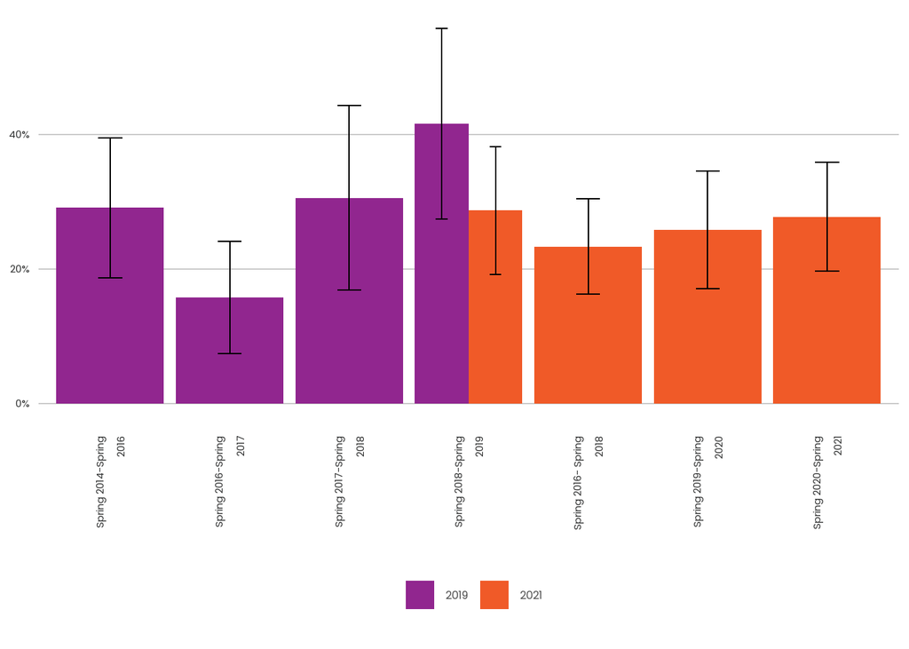

```r
static_column_chart(t=displaced_2019_2021_counts, x='move_year', y='share', fill='survey', moe='share_moe', color=  "pognbgy_5")+ theme(axis.text.x = element_text(angle = 90, vjust = 0.5, hjust=1))
```

```r
hhs_2021<-get_hhts(survey='2021', level="h", vars=c("res_dur",
"res_factors_30min",
"res_factors_afford",
"res_factors_closefam",
"res_factors_hwy",
"res_factors_school",
"res_factors_space",
"res_factors_transit",
"res_factors_walk",
"res_factors_cultural",
'prev_home_wa'

))%>%filter(res_dur %in% c('Less than a year' , 'Between 1 and 2 years'))



vars_to_summarize<-c(
"res_factors_30min",
"res_factors_afford",
"res_factors_closefam",
"res_factors_hwy",
"res_factors_school",
"res_factors_space",
"res_factors_transit",
"res_factors_walk",
"res_factors_cultural")



mover_sum<- list()
mover_sum <- lapply(vars_to_summarize, FUN=function(x) hhts_count(df=hhs_2021,group_vars=c(x))) %>%
    lapply(FUN=function(y){mutate(y, "var_name"=colnames(y)[2])}) %>% data.table::rbindlist(use.names=FALSE) %>%
    rename(var_value=colnames(.)[2]) %>% relocate(var_name)

mover_shares_2021<-mover_sum%>% select(var_name, var_value, share,survey, share_moe)%>%filter(var_value=='Very important')
```

```r
hhs_2019<-get_hhts(survey='2019', level="h", vars=c("res_dur",
"res_factors_30min",
"res_factors_afford",
"res_factors_closefam",
"res_factors_hwy",
"res_factors_school",
"res_factors_space",
"res_factors_transit",
"res_factors_walk"
))%>%filter(res_dur %in% c('Less than a year' , 'Between 1 and 2 years'))



vars_to_summarize<-c(
"res_factors_30min",
"res_factors_afford",
"res_factors_closefam",
"res_factors_hwy",
"res_factors_school",
"res_factors_space",
"res_factors_transit",
"res_factors_walk")



mover_sum<- list()
mover_sum <- lapply(vars_to_summarize, FUN=function(x) hhts_count(df=hhs_2019,group_vars=c(x))) %>%
    lapply(FUN=function(y){mutate(y, "var_name"=colnames(y)[2])}) %>% rbindlist(use.names=FALSE) %>%
    rename(var_value=colnames(.)[2]) %>% relocate(var_name)

mover_shares_2019<-mover_sum%>% select(var_name, var_value, share,survey, share_moe)%>%filter(var_value=='Very important')
```

Why did you move To current residence

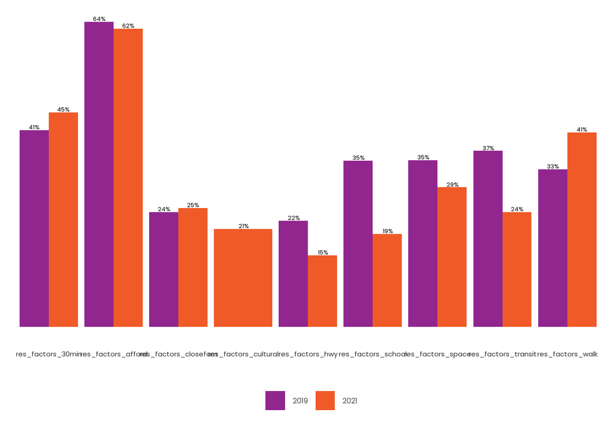

```r
mover_shares_19_21<-rbind(mover_shares_2019, mover_shares_2021)%>%mutate(var_name=str_wrap(var_name,10))

static_column_chart(mover_shares_19_21, x='var_name' , y='share', fill='survey', color= "pognbgy_5")
```

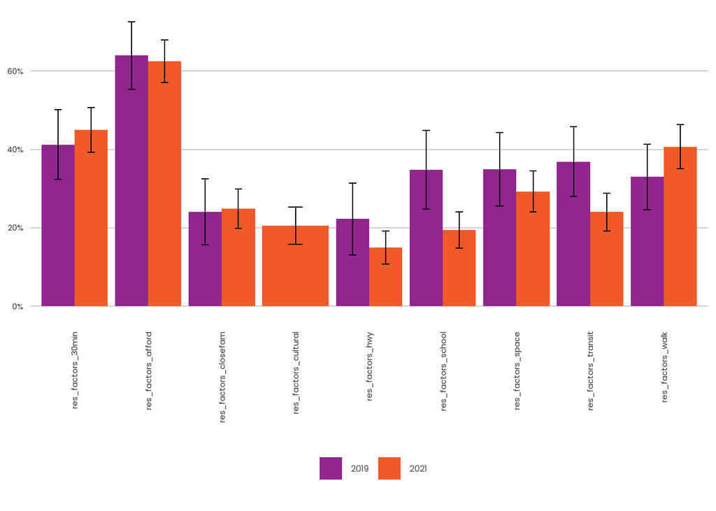

```r
static_column_chart(mover_shares_19_21, x='var_name' , y='share', fill='survey', color= "pognbgy_5", moe='share_moe')+ theme(axis.text.x = element_text(angle = 90, vjust = 0.5, hjust=1))
```

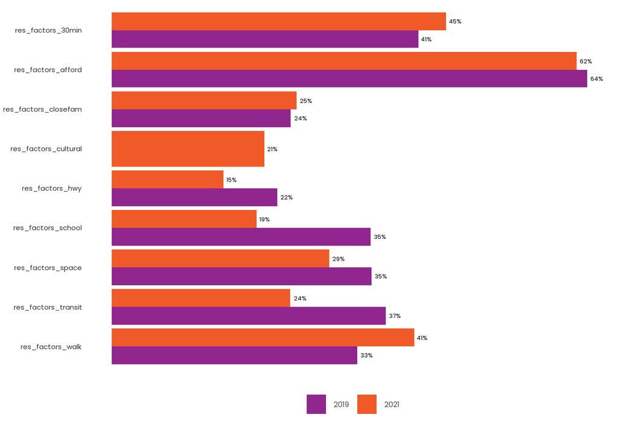

```r
static_bar_chart(mover_shares_19_21, y='var_name' , x='share', fill='survey', color= "pognbgy_5")
```

```r
hhs_2019<-get_hhts(survey='2019', level="h", vars=c("res_dur",
"prev_res_factors_housing_cost",
"prev_res_factors_income_change",
"prev_res_factors_community_change",
"prev_res_factors_hh_size",
"prev_res_factors_more_space",
"prev_res_factors_less_space",
"prev_res_factors_employment",
"prev_res_factors_covid_flexibility",
"prev_res_factors_school",
"prev_res_factors_crime",
"prev_res_factors_covid_health",
"prev_res_factors_quality",
"prev_res_factors_forced",
"prev_res_factors_no_answer",
"prev_res_factors_other",
"prev_res_factors_specify"

))%>%drop_na(prev_res_factors_housing_cost)



vars_to_summarize<-c(
"prev_res_factors_housing_cost",
"prev_res_factors_income_change",
"prev_res_factors_community_change",
"prev_res_factors_hh_size",
"prev_res_factors_more_space",
"prev_res_factors_less_space",
"prev_res_factors_employment",
"prev_res_factors_covid_flexibility",
"prev_res_factors_school",
"prev_res_factors_crime",
"prev_res_factors_covid_health",
"prev_res_factors_quality",
"prev_res_factors_forced",
"prev_res_factors_no_answer",
"prev_res_factors_other",
"prev_res_factors_specify")




mover_sum<- list()
mover_sum <- lapply(vars_to_summarize, FUN=function(x) hhts_count(df=hhs_2019,group_vars=c(x))) %>%
    lapply(FUN=function(y){mutate(y, "var_name"=colnames(y)[2])}) %>% rbindlist(use.names=FALSE) %>%
    rename(var_value=colnames(.)[2]) %>% relocate(var_name)

mover_shares_2019<-mover_sum%>% select(var_name, var_value, share,survey, share_moe)%>%filter(var_value=='Selected')
```

```r
hhs_2021<-get_hhts(survey='2021', level="h", vars=c("res_dur",
"prev_res_factors_housing_cost",
"prev_res_factors_income_change",
"prev_res_factors_community_change",
"prev_res_factors_hh_size",
"prev_res_factors_more_space",
"prev_res_factors_less_space",
"prev_res_factors_employment",
"prev_res_factors_covid_flexibility",
"prev_res_factors_school",
"prev_res_factors_crime",
"prev_res_factors_covid_health",
"prev_res_factors_quality",
"prev_res_factors_forced",
"prev_res_factors_no_answer",
"prev_res_factors_other",
"prev_res_factors_specify"

))%>%drop_na(prev_res_factors_housing_cost)%>%mutate(displacement_recode= case_when(
  prev_res_factors_forced == 'Selected' ~ 'Displaced'
))



vars_to_summarize<-c(
"prev_res_factors_housing_cost",
"prev_res_factors_income_change",
"prev_res_factors_community_change",
"prev_res_factors_hh_size",
"prev_res_factors_more_space",
"prev_res_factors_less_space",
"prev_res_factors_employment",
"prev_res_factors_covid_flexibility",
"prev_res_factors_school",
"prev_res_factors_crime",
"prev_res_factors_covid_health",
"prev_res_factors_quality",
"prev_res_factors_forced",
"prev_res_factors_no_answer",
"prev_res_factors_other",
"prev_res_factors_specify")



mover_sum<- list()
mover_sum <- lapply(vars_to_summarize, FUN=function(x) hhts_count(df=hhs_2021,group_vars=c(x))) %>%
    lapply(FUN=function(y){mutate(y, "var_name"=colnames(y)[2])}) %>% rbindlist(use.names=FALSE) %>%
    rename(var_value=colnames(.)[2]) %>% relocate(var_name)

mover_shares_2021<-mover_sum%>% select(var_name, var_value, share,survey, share_moe)%>%filter(var_value=='Selected')
```

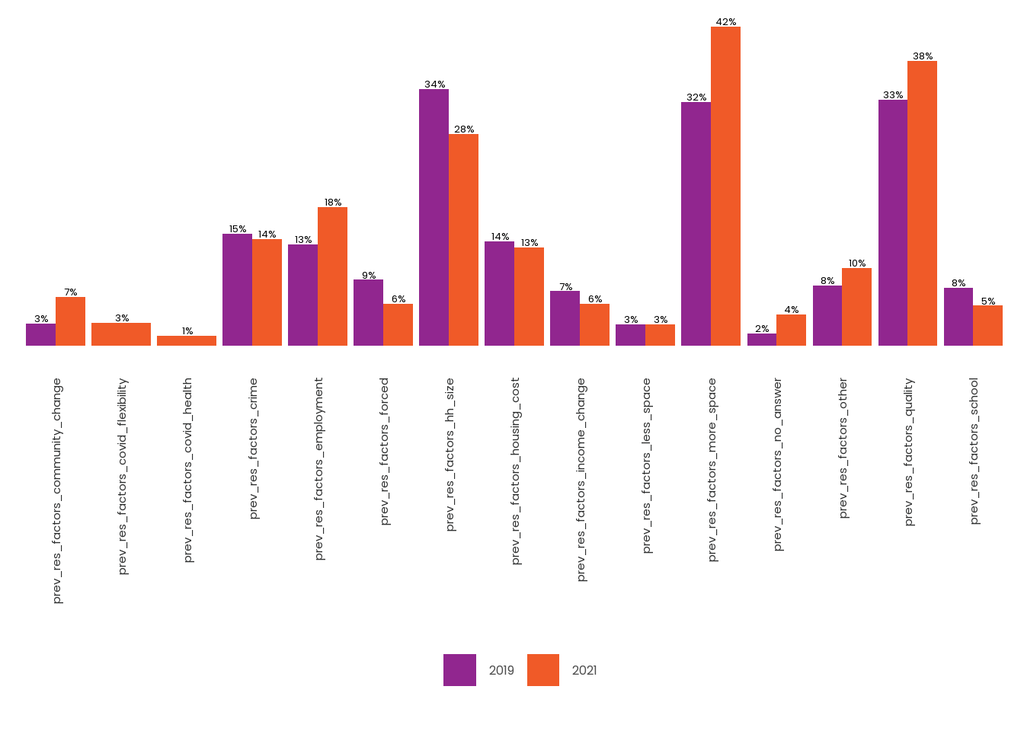

```r
mover_shares_19_21<-rbind(mover_shares_2019, mover_shares_2021)%>%mutate(var_name=str_wrap(var_name,10))

static_column_chart(mover_shares_19_21, x='var_name' , y='share', fill='survey', color= "pognbgy_5")+ theme(axis.text.x = element_text(angle = 90, vjust = 0.5, hjust=1))
```

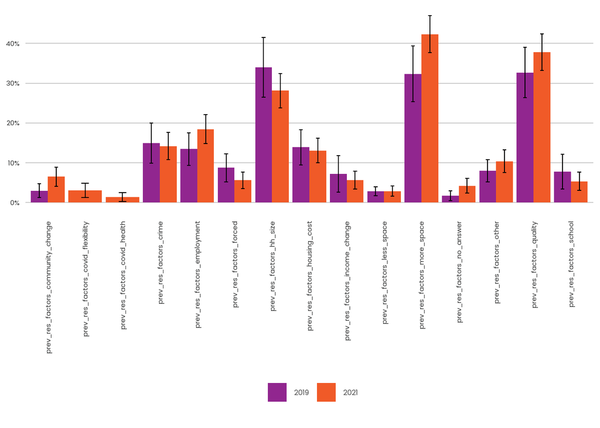

```r
static_column_chart(mover_shares_19_21, x='var_name' , y='share', fill='survey', color= "pognbgy_5", moe='share_moe')+ theme(axis.text.x = element_text(angle = 90, vjust = 0.5, hjust=1))
```

redefining

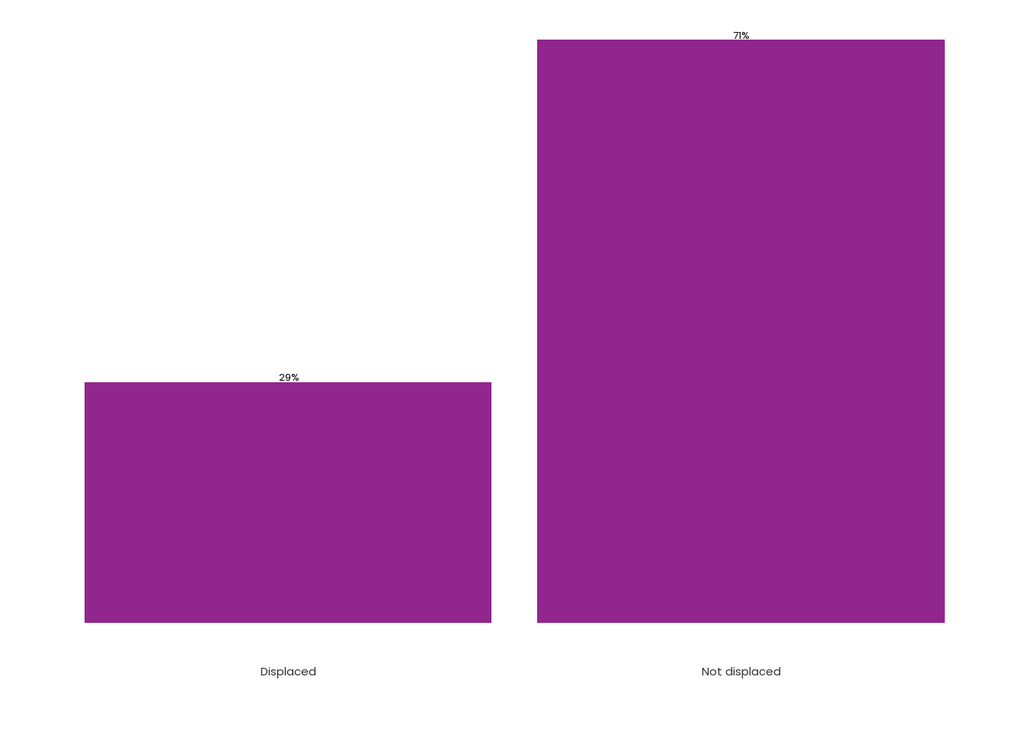

```r
displaced_hh_2019<-get_hhts(survey='2019', level="h", vars=c("prev_res_factors_displaced", "prev_res_factors_housing_cost", "prev_res_factors_forced", "prev_res_factors_income_change", "prev_res_factors_community_change", 'res_dur', 'prev_home_wa'))%>%filter(res_dur %in% c('Less than a year', ' Between 1 and 2 years', 'Between 2 and 3 years',    'Between 3 and 5 years') & prev_home_wa =='Yes, previous home was in Washington')%>%
  mutate(prev_res_factors_displaced_2 =case_when(prev_res_factors_housing_cost=='Selected' |
                                                   prev_res_factors_forced=='Selected' |
                                                   prev_res_factors_income_change=='Selected' |                prev_res_factors_community_change=='Selected'~ 'Displaced',
  TRUE ~ 'Not displaced')   )

displaced_hh_2019_counts<- hhts_count(df=displaced_hh_2019, group_vars='prev_res_factors_displaced_2')%>%
filter(prev_res_factors_displaced_2!='Total')

static_column_chart(t=displaced_hh_2019_counts, x='prev_res_factors_displaced_2', y='share', fill='survey',color=  "pognbgy_5")
```

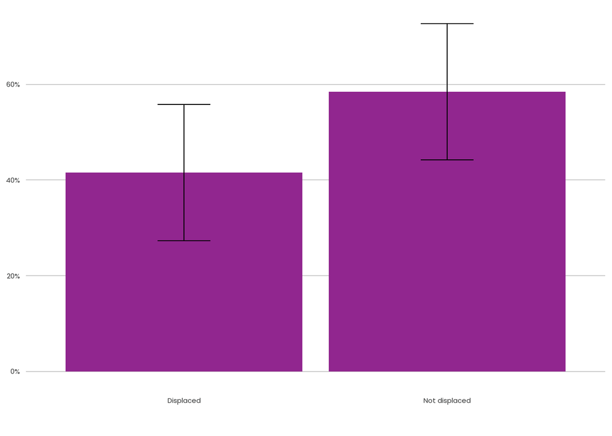

```r
displaced_hh_2019<-get_hhts(survey='2019', level="h", vars=c("prev_res_factors_displaced", "prev_res_factors_housing_cost", "prev_res_factors_forced", "prev_res_factors_income_change", "prev_res_factors_community_change", 'res_dur', 'prev_home_wa', 'hh_race_apoc', 'hhincome_broad' ))%>%filter(res_dur %in% c('Less than a year', '  Between 1 and 2 years') & prev_home_wa =='Yes, previous home was in Washington')%>%
  mutate(prev_res_factors_displaced_2 =case_when(prev_res_factors_housing_cost=='Selected' |                                                 prev_res_factors_forced=='Selected' |                                                  prev_res_factors_income_change=='Selected' |                prev_res_factors_community_change=='Selected'~ 'Displaced',
  TRUE ~ 'Not displaced') )  %>%                                                                                                                                   mutate(prev_res_factors_displaced = replace_na(prev_res_factors_displaced,'No response'))%>%mutate(hhincome_100_f=factor(hhincome_broad, levels=c("Under $25,000" , "$25,000-$49,999" ,  "$50,000-$74,999" , "$75,000-$99,999", "$100,000 or more",'$200,000 or more', "Prefer not to answer")))



displaced_hh_2019_counts<- hhts_count(df=displaced_hh_2019, group_vars='prev_res_factors_displaced_2')%>%
filter(prev_res_factors_displaced_2!='Total')

static_column_chart(t=displaced_hh_2019_counts, x='prev_res_factors_displaced_2', y='share', fill='survey', moe='share_moe',color=  "pognbgy_5")
```

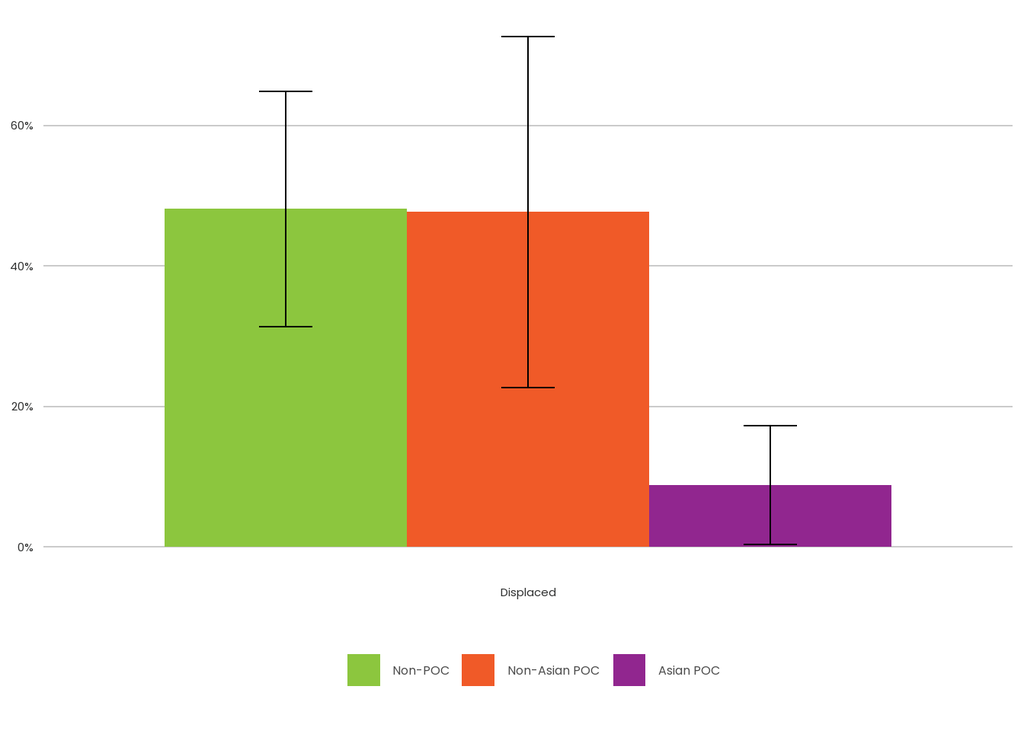

```r
displaced_hh_2019_counts<- hhts_count(df=displaced_hh_2019, group_vars=c('hh_race_apoc','prev_res_factors_displaced_2'))%>%
filter(prev_res_factors_displaced_2!='Total')%>%
  filter(hh_race_apoc!='Total')%>%filter(prev_res_factors_displaced_2=='Displaced')%>%
  filter(hh_race_apoc != 'Missing') %>%
  mutate(hh_race_high_low= fct_reorder(hh_race_apoc, -share))

static_column_chart(t=displaced_hh_2019_counts, x='prev_res_factors_displaced_2', y='share', fill='hh_race_high_low',color=  "pognbgy_10", moe='share_moe')
```

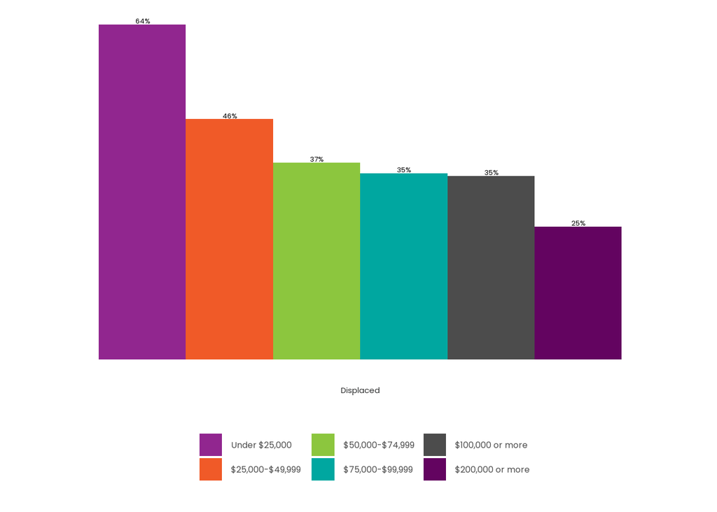

```r
displaced_hh_2019_counts<- hhts_count(df=displaced_hh_2019, group_vars=c('hhincome_100_f','prev_res_factors_displaced_2'))%>%
filter(prev_res_factors_displaced_2!='Total')%>%filter(hhincome_100_f !='Total')%>%filter(prev_res_factors_displaced_2=='Displaced')

static_column_chart(t=displaced_hh_2019_counts, x='prev_res_factors_displaced_2', y='share', fill='hhincome_100_f',color=  "pognbgy_10")
```

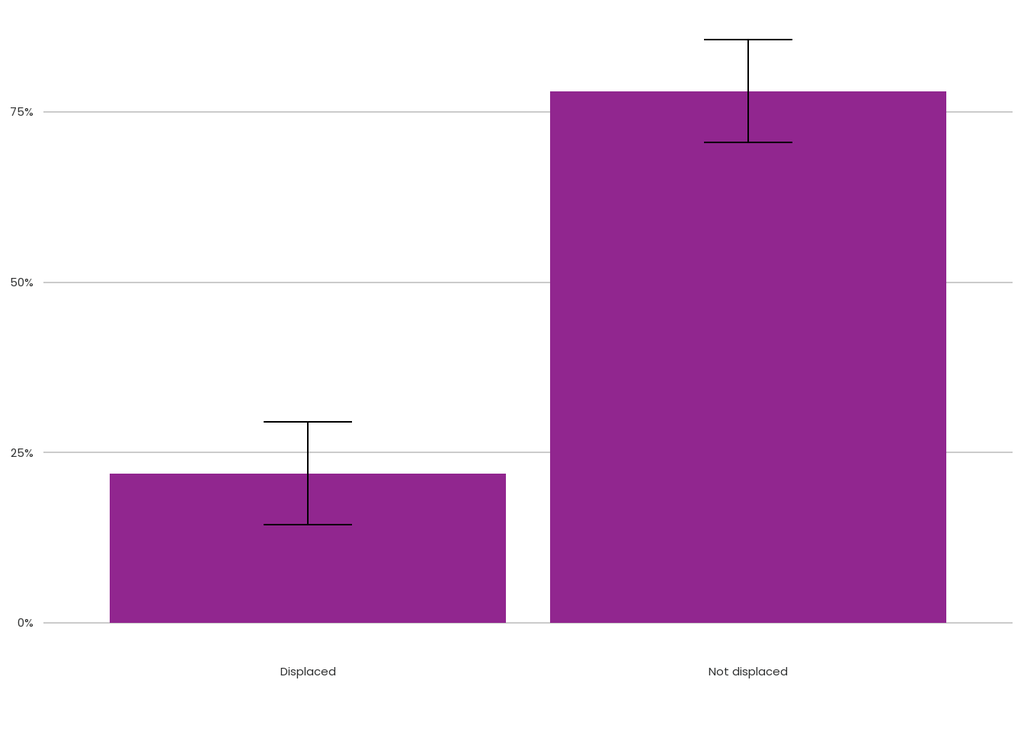

```r
displaced_hh_2021<-get_hhts(survey='2021', level="h", vars=c("prev_res_factors_displaced", "prev_res_factors_housing_cost", "prev_res_factors_forced", "prev_res_factors_income_change", 'res_dur', 'prev_home_wa', 'hh_race_apoc', 'hhincome_broad' ))%>%filter(res_dur %in% c('Less than a year', '   Between 1 and 2 years') & prev_home_wa =='Yes, previous home was in Washington')%>%
  mutate(prev_res_factors_displaced_2 =case_when((prev_res_factors_housing_cost=='Selected' |
                                                   prev_res_factors_forced=='Selected' |
                                              prev_res_factors_income_change=='Selected')~ "Displaced",
  TRUE ~ 'Not displaced') )  %>%                                                 mutate(prev_res_factors_displaced = replace_na(prev_res_factors_displaced,'No response'))%>%mutate(hhincome_100_f=factor(hhincome_broad, levels=c("Under $25,000" , "$25,000-$49,999" ,  "$50,000-$74,999" , "$75,000-$99,999",
"$100,000-$199,000",'$200,000 or more', "Prefer not to answer")))



displaced_hh_2021_counts<- hhts_count(df=displaced_hh_2021, group_vars='prev_res_factors_displaced_2')%>%
filter(prev_res_factors_displaced_2!='Total')

static_column_chart(t=displaced_hh_2021_counts, x='prev_res_factors_displaced_2', y='share', fill='survey', moe='share_moe',color=  "pognbgy_5")
```

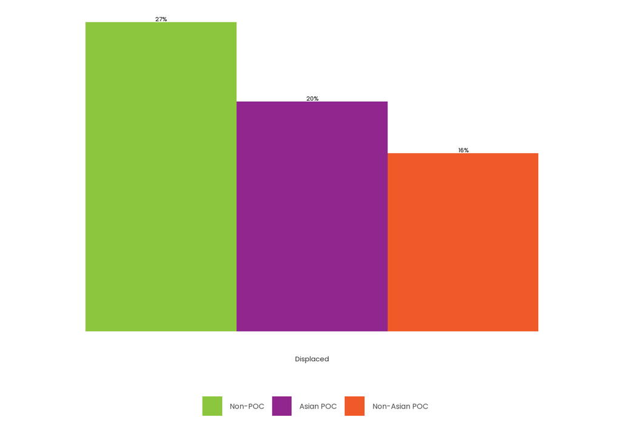

```r
displaced_hh_2021_counts<- hhts_count(df=displaced_hh_2021, group_vars=c('hh_race_apoc','prev_res_factors_displaced_2'))%>%
filter(prev_res_factors_displaced_2!='Total')%>%
  filter(hh_race_apoc!='Total')%>%filter(prev_res_factors_displaced_2=='Displaced')%>%
  filter(hh_race_apoc != 'Missing') %>%
  mutate(hh_race_high_low= fct_reorder(hh_race_apoc, -share))

static_column_chart(t=displaced_hh_2021_counts, x='prev_res_factors_displaced_2', y='share', fill='hh_race_high_low',color=  "pognbgy_10")
```

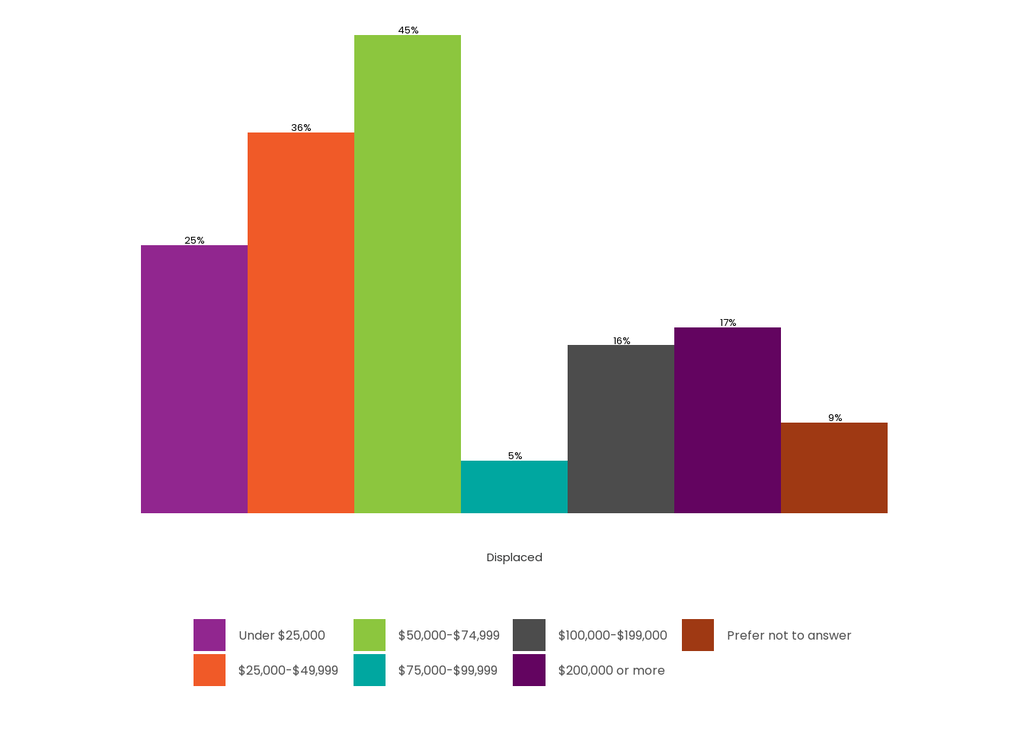

```r
displaced_hh_2021_counts<- hhts_count(df=displaced_hh_2021, group_vars=c('hhincome_100_f','prev_res_factors_displaced_2'))%>%
filter(prev_res_factors_displaced_2!='Total')%>%filter(hhincome_100_f !='Total')%>%filter(prev_res_factors_displaced_2=='Displaced')

static_column_chart(t=displaced_hh_2021_counts, x='prev_res_factors_displaced_2', y='share', fill='hhincome_100_f',color=  "pognbgy_10")
```

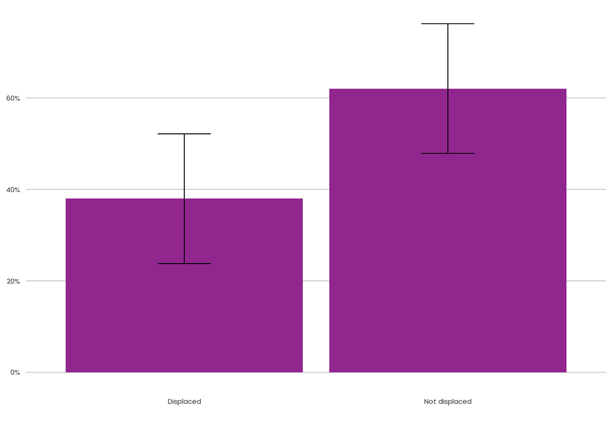

```r
displaced_hh_2019<-get_hhts(survey='2019', level="h", vars=c("prev_res_factors_displaced", "prev_res_factors_housing_cost", "prev_res_factors_forced", "prev_res_factors_income_change",  'res_dur', 'prev_home_wa', 'hh_race_apoc', 'hhincome_broad' ))%>%filter(res_dur %in% c('Less than a year', '  Between 1 and 2 years') & prev_home_wa =='Yes, previous home was in Washington')%>%
  mutate(prev_res_factors_displaced_2 =case_when(prev_res_factors_housing_cost=='Selected' |
                                                   prev_res_factors_forced=='Selected' |
                                                   prev_res_factors_income_change=='Selected' ~ 'Displaced',
  TRUE ~ 'Not displaced') )  %>%                                                                                                                                   mutate(prev_res_factors_displaced = replace_na(prev_res_factors_displaced,'No response'))%>%mutate(hhincome_100_f=factor(hhincome_broad, levels=c("Under $25,000" , "$25,000-$49,999" ,  "$50,000-$74,999" , "$75,000-$99,999", "$100,000 or more",'$200,000 or more', "Prefer not to answer")))



displaced_hh_2019_counts<- hhts_count(df=displaced_hh_2019, group_vars='prev_res_factors_displaced_2')%>%
filter(prev_res_factors_displaced_2!='Total')

static_column_chart(t=displaced_hh_2019_counts, x='prev_res_factors_displaced_2', y='share', fill='survey', moe='share_moe',color=  "pognbgy_5")
```

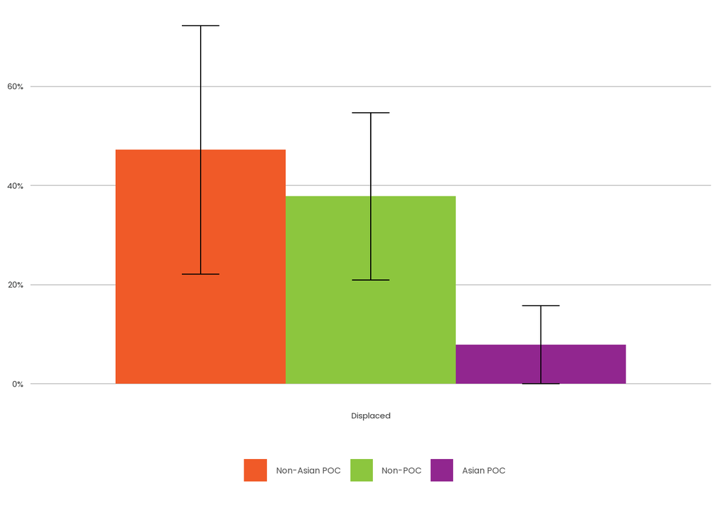

```r
displaced_hh_2019_counts<- hhts_count(df=displaced_hh_2019, group_vars=c('hh_race_apoc','prev_res_factors_displaced_2'))%>%
filter(prev_res_factors_displaced_2!='Total')%>%
  filter(hh_race_apoc!='Total')%>%filter(prev_res_factors_displaced_2=='Displaced')%>%
  filter(hh_race_apoc != 'Missing') %>%
  mutate(hh_race_high_low= fct_reorder(hh_race_apoc, -share))

static_column_chart(t=displaced_hh_2019_counts, x='prev_res_factors_displaced_2', y='share', fill='hh_race_high_low',color=  "pognbgy_10", moe='share_moe')
```

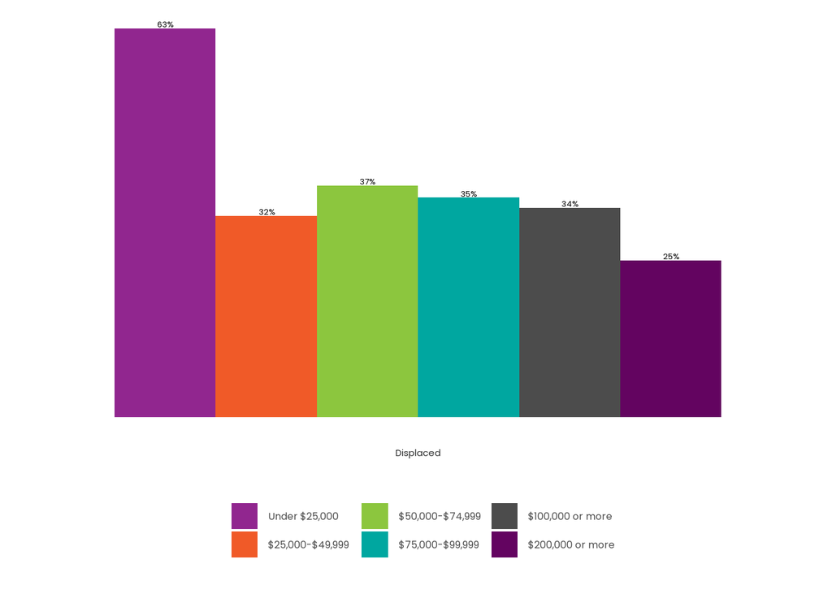

```r
displaced_hh_2019_counts<- hhts_count(df=displaced_hh_2019, group_vars=c('hhincome_100_f','prev_res_factors_displaced_2'))%>%
filter(prev_res_factors_displaced_2!='Total')%>%filter(hhincome_100_f !='Total')%>%filter(prev_res_factors_displaced_2=='Displaced')

static_column_chart(t=displaced_hh_2019_counts, x='prev_res_factors_displaced_2', y='share', fill='hhincome_100_f',color=  "pognbgy_10")
```

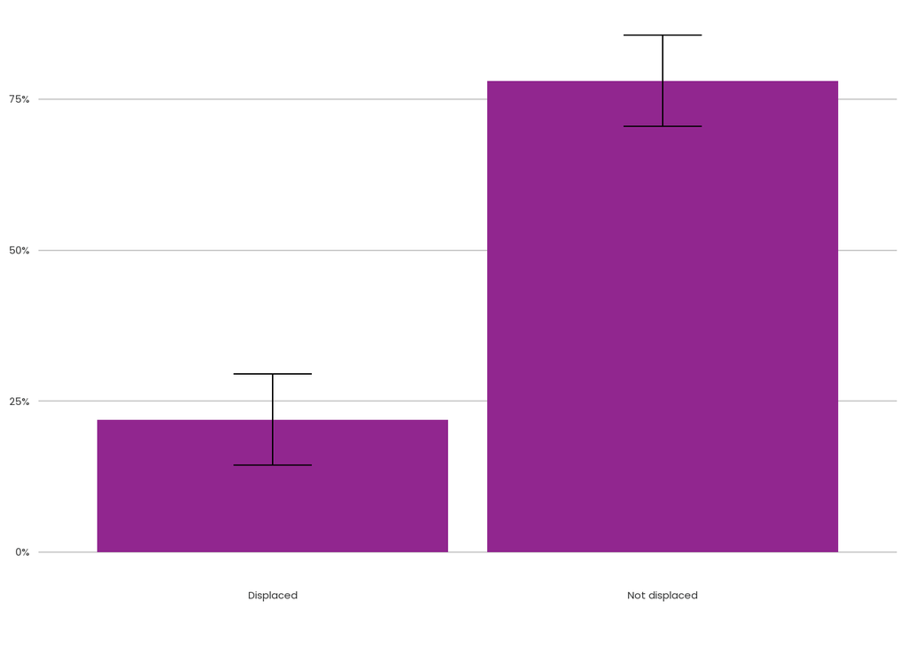

```r
displaced_hh_2021<-get_hhts(survey='2021', level="h", vars=c("prev_res_factors_displaced", "prev_res_factors_housing_cost", "prev_res_factors_forced", "prev_res_factors_income_change",  'res_dur', 'prev_home_wa', 'hh_race_apoc', 'hhincome_broad' ))%>%filter(res_dur %in% c('Less than a year', '  Between 1 and 2 years') & prev_home_wa =='Yes, previous home was in Washington')%>%
  mutate(prev_res_factors_displaced_2 =case_when(prev_res_factors_housing_cost=='Selected' |
                                                   prev_res_factors_forced=='Selected' |
                                                   prev_res_factors_income_change=='Selected' ~ "Displaced",
  TRUE ~ 'Not displaced') )  %>%                                                                                                                                   mutate(prev_res_factors_displaced = replace_na(prev_res_factors_displaced,'No response'))%>%mutate(hhincome_100_f=factor(hhincome_broad, levels=c("Under $25,000" , "$25,000-$49,999" ,  "$50,000-$74,999" , "$75,000-$99,999",
"$100,000-$199,000",'$200,000 or more', "Prefer not to answer")))



displaced_hh_2021_counts<- hhts_count(df=displaced_hh_2021, group_vars='prev_res_factors_displaced_2')%>%
filter(prev_res_factors_displaced_2!='Total')

static_column_chart(t=displaced_hh_2021_counts, x='prev_res_factors_displaced_2', y='share', fill='survey', moe='share_moe',color=  "pognbgy_5")
```

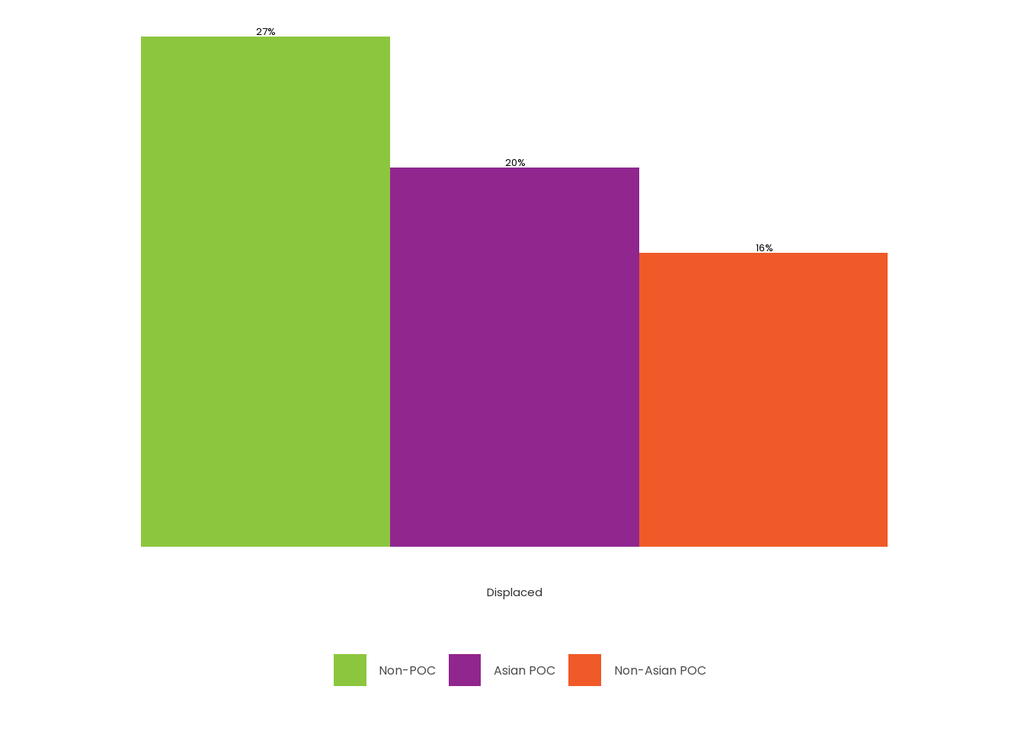

```r
displaced_hh_2021_counts<- hhts_count(df=displaced_hh_2021, group_vars=c('hh_race_apoc','prev_res_factors_displaced_2'))%>%
filter(prev_res_factors_displaced_2!='Total')%>%
  filter(hh_race_apoc!='Total')%>%filter(prev_res_factors_displaced_2=='Displaced')%>%
  filter(hh_race_apoc != 'Missing') %>%
  mutate(hh_race_high_low= fct_reorder(hh_race_apoc, -share))

static_column_chart(t=displaced_hh_2021_counts, x='prev_res_factors_displaced_2', y='share', fill='hh_race_high_low',color=  "pognbgy_10")
```

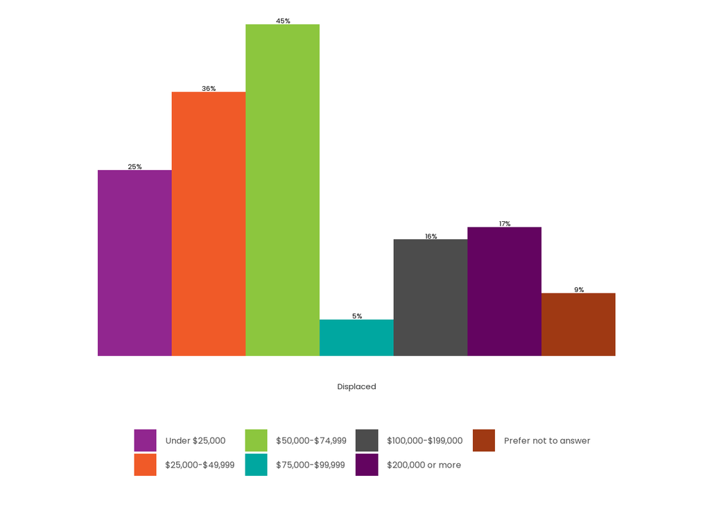

```r
displaced_hh_2021_counts<- hhts_count(df=displaced_hh_2021, group_vars=c('hhincome_100_f','prev_res_factors_displaced_2'))%>%
filter(prev_res_factors_displaced_2!='Total')%>%filter(hhincome_100_f !='Total')%>%filter(prev_res_factors_displaced_2=='Displaced')

static_column_chart(t=displaced_hh_2021_counts, x='prev_res_factors_displaced_2', y='share', fill='hhincome_100_f',color=  "pognbgy_10")
```